# The many shades of Fama-MacBeth

# 1 Introduction

This notebook generates the results of the third study in the paper **Forking paths in empirical studies** available on [SSRN](https://papers.ssrn.com/sol3/papers.cfm?abstract_id=3999379).

The **code** is folded to ease readability. Click on the corresponding buttons to access it.

# 2 Data & packages

First we load the few packages we will need.  
Then, we download the data **locally**. We do this to speed up computation times later on so that each call does not need to fetch the data all over again.  
While we could build a large tidy dataset with all portfolios returns (across dates, assets and asset types), we rely on a brute force approach that stores samples *separately*. This in fact save some time, as we will not have to filter and pivot the data to a wide format: these steps, when repeated many fold, are time-consuming.

**NOTE**: the data from [Ken French’s website](https://mba.tuck.dartmouth.edu/pages/faculty/ken.french/data_library.html) is subject to updates and potential instability, see [Noisy Factors](https://papers.ssrn.com/sol3/papers.cfm?abstract_id=3930228).

The data fetching script (FM_data.qmd) is available upon request.

```r
library(tidyverse)
library(quantmod)
library(DescTools)
# source(knitr::purl("FM_data.qmd", quiet=TRUE))

load("FF_factors_monthly.RData")

winso_mat <- function(m, q){
    q_min <- quantile(m[,], q, na.rm = T)
    q_max <- quantile(m[,], 1-q, na.rm = T)
    m[m < q_min] <- q_min
    m[m > q_max] <- q_max
    m
}
```

# 3 The functions

```r
fetch_asset <- function(freq, asset_file, weight, winso_1){
    load(paste0(asset_file, "_", freq, ".RData"))
    load(paste0("FF_factors_", freq, ".RData"))
    assets <- assets |> filter(weighting == weight)
    assets <- bind_cols(assets |> select(date, weighting),                 # Winsorising stage
                        assets |>
                            select(-date, -weighting) |>
                            data.matrix() |> winso_mat(winso_1) |>
                            data.frame())
    left_join(assets, FF_factors |> select(-RF), by = "date") |>   # Joining stage
        filter(is.finite(SMB))
}

pass_1 <- function(data, factors){                               # This function performs the first pass
    nb_factors <- length(factors)
    asset_names <- colnames(data |> select(-all_of(c("date", "weighting", factors))))   # Keep names of assets
    models <- lapply(paste(asset_names, ' ~  Mkt_RF + SMB + HML + RMW + CMA'),  # Specification of models
                     function(f){lm(as.formula(f), data = data) %>%             # Calling lm(.)
                             summary() %>%                                      # Gathering the output
                             "$"(coef) %>%                                      # Keeping only the coefs
                             data.frame() %>%                                   # Convert to dataframe
                             select(Estimate)}                                  # Keep the coefficients
    )

    betas <- matrix(unlist(models), ncol = nb_factors + 1, byrow = T) %>%       # Extracting the betas
        data.frame(row.names = asset_names)                                     # Formatting: row names
    colnames(betas) <- c("Constant", "Mkt_RF", "SMB", "HML", "RMW", "CMA")      # Formatting: col names
    betas
}

pass_2 <- function(FM_data, reg_type){
    factors <- c("Mkt_RF", "SMB", "HML", "RMW", "CMA")                        # Fixed for the whole study
    nb_factors <- length(factors)
    dates <- FM_data |> select(-all_of(factors)) |> colnames()
    if(reg_type != "static"){
        dates <- max(dates)
    }
    models <- lapply(paste("`", dates, "`", ' ~  Mkt_RF + SMB + HML + RMW + CMA', sep = ""),
                     function(f){
                         temp <- lm(as.formula(f), data = FM_data, y = T)   # Calling lm(.)
                         temp |> summary() %>%                              # Gathering the output
                             "$"(coef) %>%  data.frame() %>%                # Convert coefs to dataframe
                             select(Estimate) |>
                             bind_rows(tibble(Estimate = AIC(temp)),        # Add AIC & sd below
                                       tibble(Estimate = summary(temp)$sigma),
                                       tibble(Estimate = nrow(FM_data)),
                                       tibble(Estimate = sum(temp$residuals^2)),
                                       tibble(Estimate = var(temp$y)))
                     }
    )
    gammas <- matrix(unlist(models), ncol = nb_factors + 6, byrow = T) %>%  # Switch to dataframe
        data.frame(row.names = dates)                                       # & set row names
    colnames(gammas) <- c("Constant", "Mkt_RF", "SMB", "HML", "RMW", "CMA",
                          "aic", "sd", "sample_size", "sum_sq_err", "var_y") # Set col names
    gammas
}
```

# 4 The modules

```r
module_data <- function(asset_file, weight, winso_1){
    assets_monthly <- fetch_asset("monthly", asset_file, weight, winso_1)
    assets_daily <- fetch_asset("daily", asset_file, weight, winso_1)
    list(assets_monthly = assets_monthly,
         assets_daily = assets_daily)
}

module_FM <- function(dates_all, reg_type, winso_2, data){
    data_monthly <- data$assets_monthly
    data_daily <- data$assets_daily
    factors <- c("Mkt_RF", "SMB", "HML", "RMW", "CMA")              # Fixed for the whole study
    if(reg_type != "static"){                                       # Sample size for rolling regressions
        sample_size <- substr(reg_type, nchar(reg_type)-1, nchar(reg_type)) |> as.numeric()
        data_monthly <- data_monthly |> filter(date <= dates_all) |> tail(sample_size)
        data_daily <- data_daily |> filter(date <= dates_all) |> tail(sample_size*5)
    }
    data_monthly <- data_monthly[, colMeans(is.na(data_monthly)) == 0]     # Keep only assets with all observations
    data_daily <- data_daily[, colMeans(is.na(data_daily)) == 0]           # Keep only assets with all observations
    # Below we remove numeric columns with no variations
    data_monthly <- data_monthly[,c(T,T, apply(data_monthly[3:ncol(data_monthly)], 2, sd) > 0.001)]
    data_daily <- data_daily[,c(T,T, apply(data_daily[3:ncol(data_daily)], 2, sd, ) > 0.001)]
    asset_names_m <- data_monthly |> select(-all_of(c("date", "weighting", factors))) |> colnames()
    asset_names_d <- data_daily |> select(-all_of(c("date", "weighting", factors))) |> colnames()
    asset_names <- intersect(asset_names_d, asset_names_m)                 # Same names for daily & monthly
    data_daily <- data_daily |> select(all_of(c("date", "weighting", factors, asset_names)))
    data_monthly <- data_monthly |> select(all_of(c("date", "weighting", factors, asset_names)))
    betas_monthly <- pass_1(data_monthly, factors) |> data.matrix() |>     # First pass
        winso_mat(winso_2) |> data.frame()                                 # Winsorize betas
    betas_daily <- pass_1(data_daily, factors) |> data.matrix() |>         # First pass
        winso_mat(winso_2) |> data.frame()                                 # Winsorize betas
    loadings_m <- betas_monthly |> select(-Constant)                       # Keep only betas
    loadings_d <- betas_daily |> select(-Constant)                         # Keep only betas
    returns_m <- data_monthly |>                                           # Start from returns
        select(all_of(asset_names)) |>                                     # Keep the returns only
        data.frame(row.names = data_monthly$date) |>                       # Set row names
        t()
    returns_m <- returns_m[,apply(returns_m, 2, sd, ) > 0.001]             # Remove constant cols (data glitch)
    FM_data_m <- cbind(loadings_m, returns_m)
    FM_data_d <- cbind(loadings_d, returns_m)
    bind_rows(
        pass_2(FM_data_m, reg_type) |>                                   # Second pass
            rownames_to_column("date") |> mutate(freq = "monthly"),
        pass_2(FM_data_d, reg_type) |>                                   #  Second pass, on monthly returns!
            rownames_to_column("date") |> mutate(freq = "daily")
    ) |>
        mutate(reg_type = reg_type,
               winso_2 = winso_2,
               n_assets = length(asset_names))
}

FM_full <- function(asset_file = "data_yahoo",
                    weight = "EW",
                    winso_1 = 0.01,
                    pars_2 = pars_2
){
    print(asset_file)
    data <- module_data(
        asset_file = asset_file,
        weight = weight,
        winso_1 = winso_1
    )
    pmap_dfr(
        list(dates_all = pars_2$dates_all,
             reg_type = pars_2$reg_type,
             winso_2 = pars_2$winso_2),
        module_FM,
        data = data
    ) |>
        mutate(asset_file = asset_file,
               weight = weight,
               winso_1 = winso_1)
}

module_data(
    asset_file = "Sorted_25",
    weight = "EW",
    winso_1 = 0.02
) %>% # OLD PIPE !
    module_FM(
        dates_all = "1987-10-31" |> as.Date(),
        reg_type = "dynamic_24",
        winso_2 = 0.02,
        data = .)
```

| date | Constant | Mkt_RF | SMB | HML | RMW | CMA | aic | sd | sample_size | sum_sq_err | var_y | freq | reg_type | winso_2 | n_assets |
| --- | --- | --- | --- | --- | --- | --- | --- | --- | --- | --- | --- | --- | --- | --- | --- |
| 1987-09-30 | 0.0019265 | -0.0159170 | 0.0132091 | 0.0078578 | -0.0152435 | -0.0065291 | -157.5279 | 0.0089843 | 25 | 0.0015336 | 0.000127 | monthly | dynamic_24 | 0.02 | 25 |
| 1987-09-30 | -0.0039317 | 0.0740385 | -0.0098788 | -0.0159272 | -0.0407886 | -0.0007061 | -155.5813 | 0.0093410 | 25 | 0.0016578 | 0.000127 | daily | dynamic_24 | 0.02 | 25 |

Next, we span all path configurations.

```r
asset_file <- c("Sorted_25", "Sorted_100", "Industry_12", "Industry_48", "data_yahoo")
#asset_file <- c("Sorted_100")
weight <- c("EW", "VW")
winso_1 <- c(0, 0.01, 0.02)
#winso_1 <- c(0.02)
pars_1 <- expand_grid(asset_file, weight, winso_1) |>
    filter(!(asset_file == "data_yahoo" & weight == "VW"))


reg_type <- c("static", "dynamic_24", "dynamic_60")
#reg_type <- c("static", "dynamic_24")
dates_all <- FF_factors$date
dates_all <- dates_all[dates_all > "1975-01-01"]
winso_2 <- c(0, 0.01, 0.02)
#winso_2 <- c(0.02)
pars_2 <- expand_grid(dates_all, reg_type, winso_2) |>
    mutate(last_day_month = ceiling_date(ymd(dates_all), 'month') - days(1)) |>
    filter(!(reg_type == "static" & (dates_all < max(dates_all)))) |>
    filter(dates_all > "1975-01-01") |>
    select(-last_day_month)

# tictoc::tic()
# output <- FM_full(
#         asset_file = "Sorted_25",
#         weight = "EW",
#         winso_1 = 0.01,
#         pars_2 = pars_2)
# tictoc::toc()
```

```r
library(furrr)
plan(multisession, workers = 5)             # Set the number of cores
tictoc::tic()
output <- future_pmap_dfr(pars_1,
                          FM_full,
                          pars_2 = pars_2)    # Launch! 7 hours on 2019 iMac
tictoc::toc()
save(output, file = "output.RData")
```

A snapshot at the shape of the results:

```r
library(tidyverse)
library(DescTools)
load("output.RData")
head(output)
```

| date | Constant | Mkt_RF | SMB | HML | RMW | CMA | aic | sd | sample_size | sum_sq_err | var_y | freq | reg_type | winso_2 | n_assets | asset_file | weight | winso_1 |
| --- | --- | --- | --- | --- | --- | --- | --- | --- | --- | --- | --- | --- | --- | --- | --- | --- | --- | --- |
| 1975-01-31 | -0.0162435 | 0.1678035 | 0.1273486 | 0.0820008 | -0.0043180 | -0.0181090 | -187.8139 | 0.0049026 | 25 | 0.0004567 | 0.0043537 | monthly | dynamic_24 | 0.00 | 25 | Sorted_25 | EW | 0 |
| 1975-01-31 | -0.0228837 | 0.1695414 | 0.1407183 | 0.0739570 | 0.0250056 | -0.0104215 | -145.5609 | 0.0114137 | 25 | 0.0024752 | 0.0043537 | daily | dynamic_24 | 0.00 | 25 | Sorted_25 | EW | 0 |
| 1975-01-31 | -0.0000225 | 0.1525194 | 0.1284641 | 0.0829089 | -0.0016077 | -0.0162033 | -180.1899 | 0.0057101 | 25 | 0.0006195 | 0.0043537 | monthly | dynamic_24 | 0.01 | 25 | Sorted_25 | EW | 0 |
| 1975-01-31 | -0.0258171 | 0.1737020 | 0.1395263 | 0.0740132 | 0.0299035 | -0.0099173 | -145.4434 | 0.0114406 | 25 | 0.0024869 | 0.0043537 | daily | dynamic_24 | 0.01 | 25 | Sorted_25 | EW | 0 |
| 1975-01-31 | 0.0101020 | 0.1445578 | 0.1264403 | 0.0851223 | 0.0053689 | -0.0117975 | -169.8246 | 0.0070255 | 25 | 0.0009378 | 0.0043537 | monthly | dynamic_24 | 0.02 | 25 | Sorted_25 | EW | 0 |
| 1975-01-31 | -0.0278045 | 0.1757247 | 0.1394500 | 0.0746526 | 0.0314142 | -0.0097861 | -144.4232 | 0.0116764 | 25 | 0.0025904 | 0.0043537 | daily | dynamic_24 | 0.02 | 25 | Sorted_25 | EW | 0 |

Below, we plot the values of risk premia, averaged annually (and across paths). We provide 2 averaging methods (simple in orange and Bayesian in blue).  
In addition, the yellow areas depict the inter-quartile range (across paths).  
The Bayesian confidence intervals are indistinguishable from the blue lines.

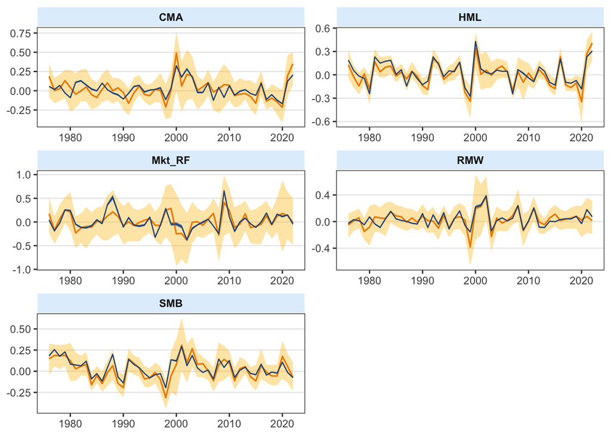

```r
data_graph <- output |>
    mutate(date = as.Date(date),
           year = year(date)) |>
    pivot_longer(Constant:CMA, names_to = "factor", values_to = "premium") |>
    mutate(premium = premium * 12) |>
    filter(factor != "Constant", year > 1975, year < 2023) |>
    group_by(date, factor) |>
    mutate(prem_winso = Winsorize(premium, probs = c(0.01, 0.99), na.rm = T),
           D = (aic - min(aic)),
           weight_freq = if_else(is.na(D), 0, exp(-D/2) / sum(exp(-D/2), na.rm = T)),
           b_freq = sum(weight_freq * premium, na.rm = T),
           lik = sqrt(sample_size/(sample_size+1))/((sum_sq_err+var_y)/(sqrt(sample_size)+1))^(sqrt(sample_size-1)),
           weight_bayes = lik/sum(lik, na.rm = T),
           b_bayes = sum(premium*weight_bayes, na.rm = T)
    ) |>
    group_by(date, year, factor) |>
    summarise(
        prem_winso = mean(prem_winso),
        b_freq = mean(b_freq),
        b_bayes = mean(b_bayes),
        s_freq = sum(weight_freq * sqrt(sd^2+(b_freq-premium)^2), na.rm = T),
        s_Bayesian = sum(weight_bayes * sqrt(sd^2+(b_bayes-premium)^2), na.rm = T),
        n = n(),
        b_up = b_bayes + 2.58*s_Bayesian/sqrt(n),
        b_down = b_bayes - 2.58*s_Bayesian/sqrt(n),
        prem_25 = quantile(premium, 0.25, na.rm = T),
        prem_75 = quantile(premium, 0.75, na.rm = T)
    ) |>
    group_by(year, factor) |>
    summarise(
        avg_premium = mean(prem_winso, na.rm = T),
        prem_25 = mean(prem_25),
        prem_75 = mean(prem_75),
        b_bayes = mean(b_bayes),
        b_up = mean(b_up),
        b_down = mean(b_down)
    )

data_graph |>
    ggplot(aes(x = year, y = avg_premium)) +
    geom_ribbon(aes(ymin = prem_25, ymax = prem_75), fill = "#FFBE02", alpha = 0.36) +
    geom_ribbon(aes(ymin = b_down, ymax = b_up), alpha = 0.7, fill = "#1863B8") +
    geom_line(color = "#EC8C01", size = 0.6) + theme_bw() +
    geom_line(aes(y = b_bayes), color = "#255081", size = 0.45) +
    theme(legend.position = c(0.75,0.15),
          panel.grid.major.x = element_blank(),
          panel.grid.minor = element_blank(),
          strip.text = element_text(face = "bold"),
          strip.background = element_rect(fill = "#E1EFFD", color = "white"),
          legend.title = element_text(face = "bold"),
          axis.title = element_blank()) +
    facet_wrap(vars(factor), ncol = 2, scales = "free") +
    guides(fill=guide_legend(nrow = 2, byrow = TRUE))
```

```r
ggsave("FM.pdf", width = 8, height = 6)
```

Below, we show the frequentist average.  
The narrow grey area around the line is the path-driven confidence interval (1% level).

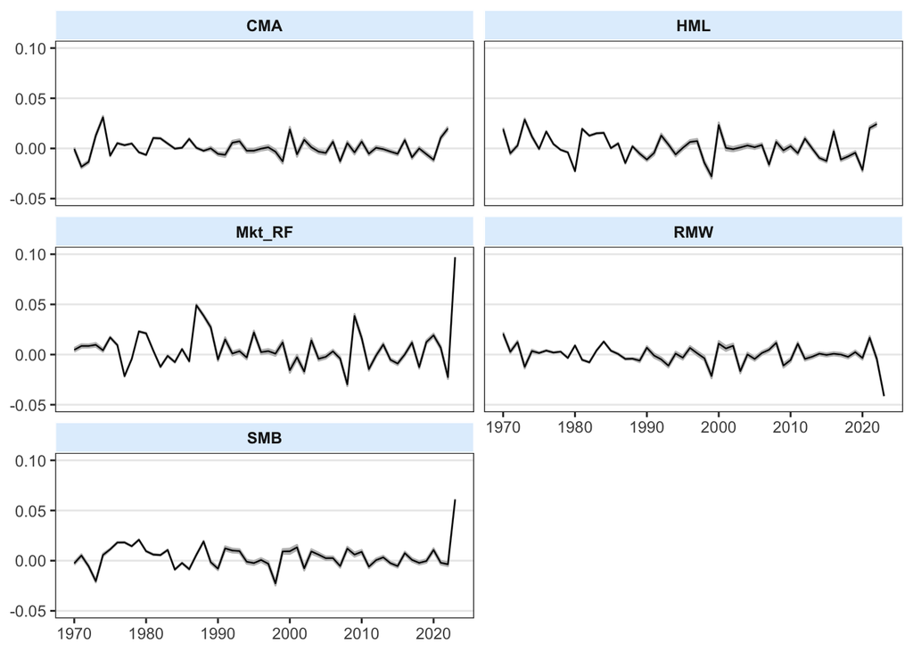

```r
output |>
    mutate(date = as.Date(date),
           year = year(date)) |>
    pivot_longer(Constant:CMA, names_to = "factor", values_to = "premium") |>
    filter(factor != "Constant") |>
    group_by(date, factor) |>
    mutate(D = (aic - min(aic)),
           year = year(date),
           weight_freq = if_else(is.na(D), 0, exp(-D/2) / sum(exp(-D/2), na.rm = T)),
           b_freq = sum(weight_freq * premium, na.rm = T)) |>
    group_by(year, factor) |>
    summarise(s_freq = sum(weight_freq / 12 * sqrt(sd^2+(b_freq-premium)^2), na.rm = T),
              n = n(),
              b_freq = mean(b_freq),
              b_up = b_freq + 2.58*s_freq/sqrt(n),
              b_down = b_freq - 2.58*s_freq/sqrt(n)) |>
    ggplot(aes(x = year, y = b_freq)) +
    geom_ribbon(aes(ymin = b_down, ymax = b_up), color = "grey", alpha = 0.4) +
    geom_line(linewidth = 0.4) +
    facet_wrap(vars(factor), ncol = 2) + theme_bw() +
    theme(legend.position = c(0.75,0.15),
          panel.grid.major.x = element_blank(),
          panel.grid.minor = element_blank(),
          strip.text = element_text(face = "bold"),
          strip.background = element_rect(fill = "#E1EFFD", color = "white"),
          legend.title = element_text(face = "bold"),
          axis.title = element_blank()) +
    ylim(-0.05,0.1)
```

# 5 Subsample analysis

We take a look a the two chronological halves of the samples and compare the average premia.

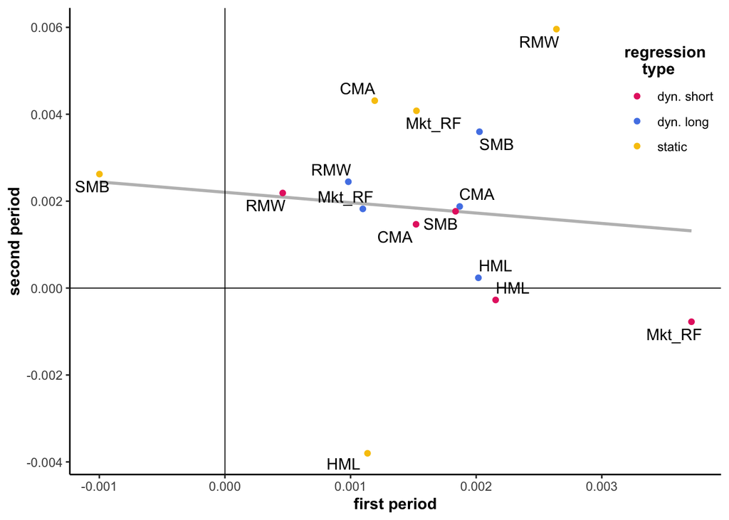

```r
library(ggrepel)
sep_date <- "1998-06-15"
output |>
    mutate(period = if_else(date < sep_date, "first_period", "second_period")) |>
    pivot_longer(Mkt_RF:CMA, values_to = "value", names_to = "factor") |>
    group_by(period, factor, reg_type) |>
    summarise(r = mean(value)) |>
    pivot_wider(names_from = period, values_from = r) |>
    ggplot(aes(x = first_period, y = second_period)) + geom_smooth(method = "lm", se = F, color = "grey") +
    #geom_smooth(method = "lm", se = F, aes(color = reg_type)) +
    geom_point(aes(color = reg_type)) +
    theme_classic() + geom_vline(xintercept = 0, linewidth = 0.3) + geom_hline(yintercept = 0, linewidth = 0.3) +
    geom_text_repel(aes(label = factor)) +
    xlab("first period") + ylab("second period") +
    theme(axis.title = element_text(face = "bold"),
          legend.position = c(0.92,0.8),
          legend.title = element_text(face = "bold")) +
    scale_color_manual(values = c("#E62D70", "#5485E7", "#F8C509"),
                       name = "regression\n    type",
                       label = c("dyn. short", "dyn. long", "static"))
```

```r
ggsave("FM_comparison.pdf", width = 8, height = 4)
```

Then the alternatives for the first pass.

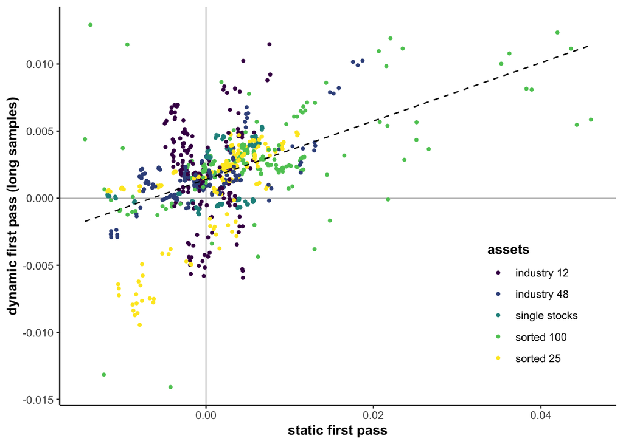

```r
output |>
    mutate(asset_file = case_when(asset_file == "data_yahoo" ~ "single stocks", .default = asset_file)) |>
    pivot_longer(Mkt_RF:CMA, values_to = "value", names_to = "factor") |>
    group_by(freq, reg_type, winso_1, winso_2, asset_file, weight, factor) |>
    summarise(value = mean(value)) |>
    pivot_wider(names_from = reg_type, values_from = value) |>
    mutate(asset_file = asset_file |> str_replace("_", " ") |> tolower()) |>
    ggplot(aes(x = static, y = dynamic_60)) + ylab("dynamic first pass (long samples)") +
    geom_vline(xintercept = 0, linewidth = 0.4, color = "grey") + geom_hline(yintercept = 0, linewidth = 0.4, color = "grey") +
    geom_point(size = 0.9, aes(color = asset_file)) + theme_classic() +
    geom_smooth(se = F, method = "lm", color = "black", linewidth = 0.5, linetype = 2) +
    scale_color_viridis_d(name = "assets") + xlab("static first pass") +
    theme(legend.position = c(0.85,0.25),
          axis.title = element_text(face = "bold"),
          legend.title = element_text(face = "bold"))
```

```r
ggsave("FM_comparison.pdf", width = 8, height = 4)
```

Below we look at 3 layers with 3 options and see if they have an impact on the average premium.  
First, regression type, then the first winsorization threshold and finally the second one.  
The first 3 columns are the average premia and the last three compute 1-2, 1-3 and 2-3 with the significance levels (simple t-tests).

```r
starz <- function(p){
    if(p < 0.001){"(***)"} else {
        if(p < 0.01){"(**)"} else{
            if(p<0.05){"(*)"}
        }
    }
}
t1 <- output |>
    pivot_longer(Mkt_RF:CMA, values_to = "value", names_to = "factor") |>
    select(date, freq, reg_type, winso_1, winso_2, asset_file, weight, factor, value) |>
    pivot_wider(names_from = reg_type, values_from = value) |>
    unnest(cols = c(dynamic_24, dynamic_60, static)) |>
    group_by(factor) |>
    summarise(m1 = (mean(dynamic_24, na.rm = T)*100) |> round(3),
              m2 = (mean(dynamic_60, na.rm = T)*100) |> round(3),
              m3 = (mean(static, na.rm = T)*100) |> round(3),
              t1 = paste(round(m1-m2,3), starz(t.test(dynamic_24, dynamic_60)$p.value)),
              t2 = paste(round(m1-m3,3), starz(t.test(dynamic_24, static)$p.value)),
              t3 = paste(round(m2-m3,3), starz(t.test(dynamic_60, static)$p.value)))

t2 <- output |>
    pivot_longer(Mkt_RF:CMA, values_to = "value", names_to = "factor") |>
    select(date, freq, reg_type, winso_1, winso_2, asset_file, weight, factor, value) |>
    pivot_wider(names_from = winso_1, values_from = value) |>
    unnest(cols = c(`0`, `0.01`, `0.02`)) |>
    group_by(factor) |>
    summarise(m1 = (mean(`0`, na.rm = T)*100) |> round(3),
              m2 = (mean(`0.01`, na.rm = T)*100) |> round(3),
              m3 = (mean(`0.02`, na.rm = T)*100) |> round(3),
              t1 = paste(round(m1-m2,3), starz(t.test(`0`, `0.01`)$p.value)),
              t2 = paste(round(m1-m3,3), starz(t.test(`0`, `0.02`)$p.value)),
              t3 = paste(round(m2-m3,3), starz(t.test(`0.01`, `0.02`)$p.value)))

t3 <- output |>
    pivot_longer(Mkt_RF:CMA, values_to = "value", names_to = "factor") |>
    select(date, freq, reg_type, winso_1, winso_2, asset_file, weight, factor, value) |>
    pivot_wider(names_from = winso_2, values_from = value) |>
    unnest(cols = c(`0`, `0.01`, `0.02`)) |>
    group_by(factor) |>
    summarise(m1 = (mean(`0`, na.rm = T)*100) |> round(3),
              m2 = (mean(`0.01`, na.rm = T)*100) |> round(3),
              m3 = (mean(`0.02`, na.rm = T)*100) |> round(3),
              t1 = paste(round(m1-m2,3), starz(t.test(`0`, `0.01`)$p.value)),
              t2 = paste(round(m1-m3,3), starz(t.test(`0`, `0.02`)$p.value)),
              t3 = paste(round(m2-m3,3), starz(t.test(`0.01`, `0.02`)$p.value)))
t1
```

| factor | m1 | m2 | m3 | t1 | t2 | t3 |
| --- | --- | --- | --- | --- | --- | --- |
| CMA | 0.149 | 0.187 | 0.264 | -0.038 (*) | -0.115 (***) | -0.077 (**) |
| HML | 0.091 | 0.110 | -0.115 | -0.019 | 0.206 (***) | 0.225 (***) |
| Mkt_RF | 0.141 | 0.147 | 0.267 | -0.006 | -0.126 (**) | -0.12 (**) |
| RMW | 0.135 | 0.173 | 0.418 | -0.038 (*) | -0.283 (***) | -0.245 (***) |
| SMB | 0.180 | 0.283 | 0.068 | -0.103 (***) | 0.112 (***) | 0.215 (***) |

```r
t2
```

| factor | m1 | m2 | m3 | t1 | t2 | t3 |
| --- | --- | --- | --- | --- | --- | --- |
| CMA | 0.430 | 0.107 | 0.070 | 0.323 (***) | 0.36 (***) | 0.037 |
| HML | -0.033 | 0.038 | 0.066 | -0.071 (**) | -0.099 (***) | -0.028 |
| Mkt_RF | 0.074 | 0.189 | 0.298 | -0.115 (**) | -0.224 (***) | -0.109 (*) |
| RMW | 0.194 | 0.267 | 0.283 | -0.073 (**) | -0.089 (***) | -0.016 |
| SMB | 0.202 | 0.146 | 0.173 | 0.056 (*) | 0.029 | -0.027 |

```r
t3
```

| factor | m1 | m2 | m3 | t1 | t2 | t3 |
| --- | --- | --- | --- | --- | --- | --- |
| CMA | 0.210 | 0.204 | 0.193 | 0.006 | 0.017 | 0.011 |
| HML | 0.021 | 0.023 | 0.027 | -0.002 | -0.006 | -0.004 |
| Mkt_RF | 0.150 | 0.194 | 0.223 | -0.044 | -0.073 | -0.029 |
| RMW | 0.235 | 0.253 | 0.256 | -0.018 | -0.021 | -0.003 |
| SMB | 0.164 | 0.177 | 0.180 | -0.013 | -0.016 | -0.003 |

```r
library(xtable)
t1 |> bind_rows(t2) |> bind_rows(t3) |> xtable(digits = 3) |> print(include.rownames=FALSE)
```

# 6 Comparison with prior work

[Fama-MacBeth](https://www.jstor.org/stable/1831028) long term premium: 0.0085. It is shown with the vertical dashed line below.  
The other values originate from the paper [Using Stocks or Portfolios in Tests of Factor Models](https://www.cambridge.org/core/journals/journal-of-financial-and-quantitative-analysis/article/abs/using-stocks-or-portfolios-in-tests-of-factor-models/55F4B00F2EE2BDEBD5F0C3EEB9752C96).

The values in the rounded rectangles are the “ease-to-replicate” indicator (90% level) defined in the paper.

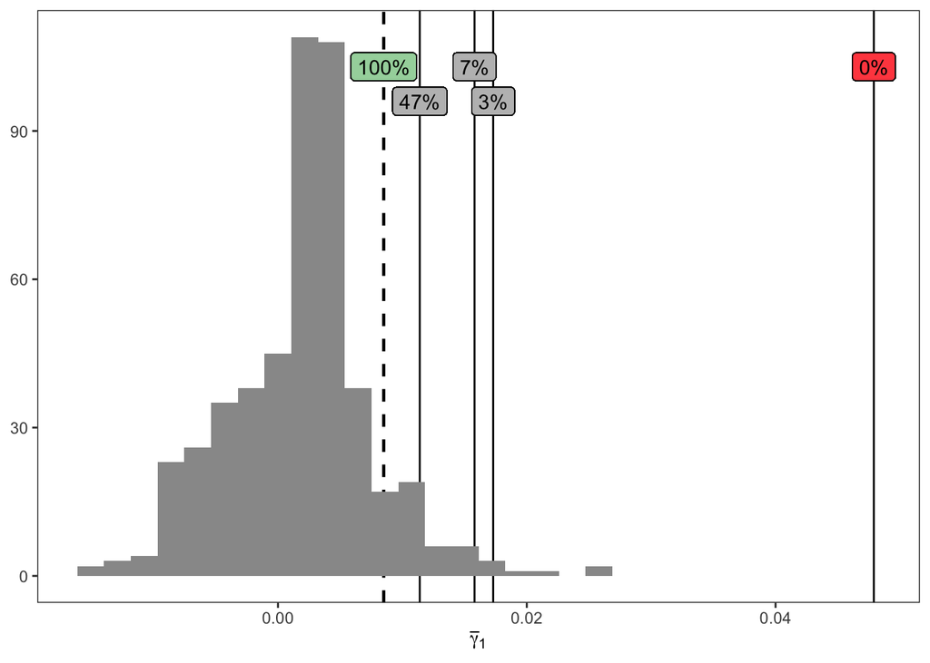

```r
library(latex2exp)
quant <- 0.9

vec_prior <- c(0.0085, 0.0114, 0.0158, 0.0173, 0.0479) # Values from prior studies

dist_FM <- output |>
    group_by(freq, reg_type, winso_1, winso_2, weight, asset_file) |>
    summarise(gamma_1 = mean(Mkt_RF))

# Odds of favorable outcome below
ofo <- pnorm(vec_prior, mean = mean(dist_FM$gamma_1), sd = sd(dist_FM$gamma_1))

dist_FM |>
    ggplot(aes(x  = gamma_1)) +
    theme_bw() +
    theme(panel.grid = element_blank(),
          axis.title.y = element_blank()) +
    geom_vline(xintercept = 0.0085, linetype = 2, linewidth = 0.8) +
    geom_vline(xintercept = 0.0114) +
    geom_vline(xintercept = 0.0158) +
    geom_vline(xintercept = 0.0173) +
    geom_vline(xintercept = 0.0479) +
    geom_histogram(fill = "#999999") +
    xlab(TeX("$\\bar{\\gamma}_1$")) +
    geom_label(aes(x = vec_prior[1], y = 103, label = paste0(round((1-if_else(ofo[1]>quant, (ofo[1]-quant)/(1-quant), 0))*100),"%")), fill = "#A4D5AA") +
    geom_label(aes(x = vec_prior[2], y = 96, label = paste0(round((1-if_else(ofo[2]>quant, (ofo[2]-quant)/(1-quant), 0))*100),"%")), fill = "grey") +
    geom_label(aes(x = vec_prior[3], y = 103, label = paste0(round((1-if_else(ofo[3]>quant, (ofo[3]-quant)/(1-quant), 0))*100),"%")), fill = "grey") +
    geom_label(aes(x = vec_prior[4], y = 96, label = paste0(round((1-if_else(ofo[4]>quant, (ofo[4]-quant)/(1-quant), 0))*100),"%")), fill = "grey") +
    geom_label(aes(x = vec_prior[5], y = 103, label = paste0(round((1-if_else(ofo[5]>quant, (ofo[5]-quant)/(1-quant), 0))*100),"%")), fill = "#FF4E4E")
```

```r
# ggsave("FM_prior.pdf", width = 8, height = 4)
```

Lastly, an illustration of the impact on the assets on the magnitude of premia.

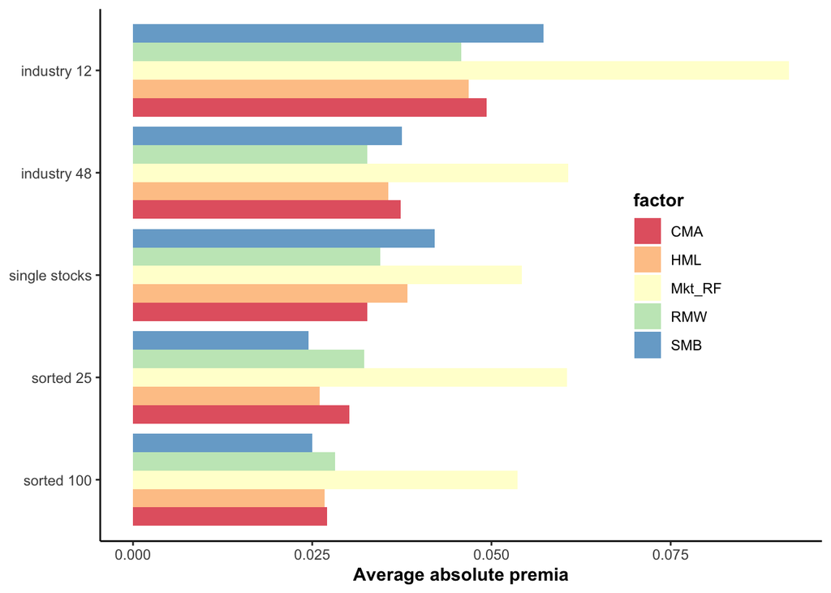

```r
output |>
    pivot_longer(Mkt_RF:CMA, values_to = "value", names_to = "factor") |>
    mutate(asset_file = case_when(asset_file == "data_yahoo" ~ "single stocks", .default = asset_file)) |>
    mutate(asset_file = asset_file |> str_replace("_", " ") |> tolower()) |>
    group_by(factor, asset_file) |>
    summarise(abs = mean(abs(value))) |>
    ggplot(aes(x = abs, y = reorder(asset_file, abs), fill = factor)) +
    geom_col(position = "dodge", alpha = 0.7) + theme_classic() +
    theme(axis.title.y = element_blank(),
          axis.title.x = element_text(face = "bold"),
          legend.title = element_text(face = "bold"),
          legend.position = c(0.8,0.5)) +
    xlab("Average absolute premia") +
    scale_fill_brewer(palette = "Spectral")
```

```r
ggsave("FM_assets.pdf", width = 8, height = 4)
```